# Brain-computer interface data classification challenge

## Training the model with the proper hyper parameters

With the hyperparameter tuning above (grid search or any), we can create the real model:

```python
subjects = createSubjectsWithResample(best_params["resample_to"])
subjs_test_stats = {}
train_cv(subjects, subjs_test_stats, test_on_last_block=False, params=best_params, write=True)
```

```python
write_results_table_custom(all_subjects, path_to_exp=experiment_res_dir)
with io.open("res/res.txt", "r", encoding="utf-8") as my_file:
    results = my_file.read()
model_val_AUC_MEAN = re.findall("AUC:.*±", results)[0][5:-1]
model_val_AUC_var = re.findall("±.*", results)[0][1:]
print("AUC mean: "+model_val_AUC_MEAN+", AUC var: "+model_val_AUC_var)
```

```
AUC mean: 0.75, AUC var: 0.06
```

## Model explanation

We will load the model of subject **25** and study its feature exctration with t-sne.

```python
subjects = createSubjectsWithResample(best_params["resample_to"])
train(subjects, test_on_last_block=False, params=best_params)
```

**1) import model state dict from the file**

```python
PATH = 'res/25/model'
model_25_state_dict = torch.load(PATH)
```

```python
print(len(model_25_state_dict))
print(model_25_state_dict.keys())
```

[output not shown]

**2) Import the data on which we will do visualisation**

```python
subjects = createSubjectsWithResample(best_params["resample_to"])
# the user corresponding to the loaded model
X, y = subjects[25]
```

```python
x, x_val, y, y_val = train_test_split(X, y, test_size=0.2, random_state=0)
```

```python
#/!\ reshape data is necessary to feed the model (cf. cv_per_subj_test and train functions )
x = x.transpose(0, 2, 1)[:, np.newaxis, :, :]
x_val = x_val.transpose(0, 2, 1)[:, np.newaxis, :, :]
print(x.shape) #(trials, kernels, channels, samples)
print(y.shape)
```

```
(263, 1, 19, 120)
(263,)
```

**3) Import a model, and load the state_dict trained weights in the model**

```python
#'''Data shape = (trials, kernels, channels, samples), which for the
#        input layer, will be (trials, 1, channels, samples).'''

#Init the model

kernLength1 = best_params.get('kernLength1',64)
kernLength2 = best_params.get('kernLength2',16)
F2 = best_params.get('F2',best_params['F1']*best_params['D'])

model_25 = EEGNet_experimental(nb_classes=2, Chans=x.shape[2], Samples=x.shape[3],
                               dropoutRates=(best_params['dropoutRate1'], best_params['dropoutRate2']),
                               kernLength1=kernLength1, kernLength2=kernLength2, poolKern1=4,
                               poolKern2=8,
                               F1=best_params['F1'],
                               D=best_params['D'], F2=F2)

# using gpu if possible (as we are not going to train anymore, but just predict, not very important)
device = torch.device('cuda:0' if torch.cuda.is_available() else 'cpu')
model_25.to(device)
```

[output not shown]

```python
model_25.load_state_dict(model_25_state_dict) # this way, we can use the pretrained weights in our model
```

```
<All keys matched successfully>
```

**4) Feeding the model to fetch the features before the last layer/classifier**

We use *forward_features()* or *forward()* methods of the model for feature exctraction and full feed forward respectively.

```python
x_tensor = torch.from_numpy(x).float()
x_test_tensor = torch.from_numpy(x_val).float()
with torch.no_grad():
    features,_ = model_25.forward_features(x_tensor)
    y_full_forward = torch.nn.Softmax(dim=1)(torch.sigmoid(model_25.forward(x_tensor)))[:, 1]
    features_test,_ = model_25.forward_features(x_test_tensor)
    y_test_full_forward = torch.nn.Softmax(dim=1)(torch.sigmoid(model_25.forward(x_test_tensor)))[:, 1]
```

```python
flatten_feats = model_25.flatten(features).numpy()
flatten_feats_test = model_25.flatten(features_test).numpy()
print(flatten_feats.shape)
```

```
(263, 252)
```

**5) Finally, applying t-SNE with the fetched flattened features and y**

```python
print(flatten_feats.shape, y.shape)
```

```
(263, 252) (263,)
```

```python
X_embedded = TSNE(n_components=2).fit_transform(flatten_feats,y)
print(X_embedded.shape)
```

```
(263, 2)
```

```python
plt.get_backend()
```

```
'module://ipykernel.pylab.backend_inline'
```

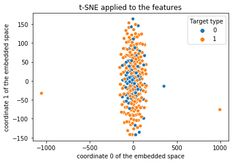

```python
sns.scatterplot(x=X_embedded.T[0], y=X_embedded.T[1], hue=y)
plt.title("t-SNE applied to the features")
plt.xlabel("coordinate 0 of the embedded space")
plt.ylabel("coordinate 1 of the embedded space")
plt.legend(title="Target type")
```

It unfortunately seems also very noisy... the model seems to have difficulties to "separate" the target and non target inputs. Nonetheless the 0-labelled points seem to be concentrated at the center. We also encounter outliers, that are oddly far away from the data distribution.

## Extension: Changing the classifier

We consider the ouput of *forward_features()* as the input of a classifier. In the pipeline, we train the EEGNet as usual on the training data, then, we hope that the *forward_features()* extract well enough the features so that we use usual classifiers on it.

As we want to use cross validation to evaluate our model, and we do not want to train the EEGNet everytimes, we chose to fix the *random_state* of the *StratifiedKFold* object to have the same train/validation splits for preatrained models (for which the weights just need to be loaded), and for classifiers.

*train_cv()* with *write=True* stores the weights of the models trained on each split:

```python
subjects = createSubjectsWithResample(best_params["resample_to"], subjs=[25])
```

```python
subjs_test_stats = {}
train_cv(subjects, subjs_test_stats, test_on_last_block=False, params=best_params, write=True)
```

```python
x = subjects[25][0]
x = x.transpose(0, 2, 1)[:, np.newaxis, :, :]
y = subjects[25][1]
```

> **Note**: We first performed a CV grid search with fixed extracted features from a model trained on the train set. But the problem is that even though the classifier does not learn from the validation data, the way the features are extracted has been learnt from the whole training data before the splitting. It means that the features extraction is already adapted to the cross validation data at every split. The classfier then easily reaches better performances than the complete EEGNet, but it is cheating somehow.

*model_cv()* solves this problem by loading the weights model trained given a certain split, and returning the output of *forward_features()* from both the training and validation data, and also returns the prediction of the complete EEGNet model on the unseen validation data:

```python
def model_cv(subj, x, y, cv_num):
    model_dict = torch.load(os.path.join("./res", str(subj), "checkpoints", str(cv_num), "model{}".format(cv_num)))
    kernLength1 = best_params.get('kernLength1',64)
    kernLength2 = best_params.get('kernLength2',16)
    F2 = best_params.get('F2',best_params['F1']*best_params['D'])

    model = EEGNet_experimental(nb_classes=2, Chans=x.shape[2], Samples=x.shape[3],
                                   dropoutRates=(best_params['dropoutRate1'], best_params['dropoutRate2']),
                                   kernLength1=kernLength1, kernLength2=kernLength2, poolKern1=4,
                                   poolKern2=8,
                                   F1=best_params['F1'],
                                   D=best_params['D'], F2=F2)

    # using gpu if possible (as we are not going to train anymore, but just predict, not very important)
    device = torch.device('cuda:0' if torch.cuda.is_available() else 'cpu')
    model.to(device)

    skf = StratifiedKFold(n_splits=4, shuffle=True, random_state=0)
    train_idx, val_idx = list(skf.split(x, y))[cv_num]

    x_tensor = torch.from_numpy(x[train_idx]).float().to(device)
    x_val_tensor = torch.from_numpy(x[val_idx]).float().to(device)
    model.load_state_dict(model_dict)

    with torch.no_grad():
        model.eval()
        features, _ = model.forward_features(x_tensor)
        features_val, _ = model.forward_features(x_val_tensor)
        y_full = torch.nn.Softmax(dim=1)(torch.sigmoid(model.forward(x_val_tensor)))[:, 1]
    return model.flatten(features).numpy(), model.flatten(features_val).numpy(), y_full.numpy()
```

Given a classifier, *compare_cv()* will return the AUC means and stds of the classifier vs complete EEGNet:

```python
def compare_cv(clf, x, y, n_split=4):

    auc_clf = []
    auc_full = []
    for cv in range(n_split):
        features, features_val, y_full_forward = model_cv(25, x, y, cv)

        skf = StratifiedKFold(n_splits=n_split, shuffle=True, random_state=0)
        train_idx, val_idx = list(skf.split(x, y))[cv]

        clf.fit(features, y[train_idx])

        auc_clf.append(roc_auc_score(y[val_idx], clf.predict(features_val)))
        auc_full.append(roc_auc_score(y[val_idx], y_full_forward))
    auc_clf = np.array(auc_clf)
    auc_full = np.array(auc_full)

    return (auc_clf.mean(), auc_clf.std()), (auc_full.mean(), auc_full.std())
```

Here is the example for **Multi layer perceptrons** (MLP):

```python
compare_cv(MLPClassifier(activation="relu", hidden_layer_sizes=(10,), alpha=1.3e-7, beta_1=0.5, beta_2=0.99,
                         max_iter=1000, learning_rate_init=best_params["lr"], tol=1e-5, random_state=0),
                                                                       x, y)
```

```
((0.8043782560007791, 0.01972396453994187),
 (0.93620064267978, 0.03383254932824955))
```

Since the hyperparameter tuning is quite time expensive in this pipeline, we did it by testing by hand some values to have roughly the best AUC validation mean. But if we had had more time, we would have used Optuna to do it. But according to the results we have, it is maybe not necessary though.

##### Results

| Classifier | AUC mean | AUC std |
| --- | --- | --- |
| EEGNet | 0.936 | 0.034 |
| MLP | 0.804 | 0.020 |
| SVM | 0.836 | 0.023 |
| Random Forest | 0.728 | 0.019 |
| LDA | 0.794 | 0.020 |

> **Note**: We obtained these results only with subject **25**. It gives us a rather good idea of the lower performance of the custom classifiers in the pipeline though. But to be sure, we would need to test those classifiers with other subjects (but time is lacking).

It seems that the feature extraction proceeded by an EEGNet si only exploitable for itself. Indeed, an MLP classifier should at least give better results in theory as it is an extension of the last layer, but it does not. This is likely to be due to overfitting reasons: the EEGNet final fully connected layer is just enough to avois overfitting. As for the other classifiers, SVM seems to be the best one (even though its AUC is far behind the EEGNet one). The conclusion with these results is that the vanilla pipeline of EEGNet seems to be the most performant, and that is the one we should consider.

## Riemannian gometry

We looked at this github repository implementing a scikit learn-like API adapted to EEG signals classification:

https://github.com/alexandrebarachant/pyRiemann

We must work directly with the EEG signals of (Trials x Channels x Time), then derive its corresponding covariance matrix of shape (Trials x Channels x Channels).µ

```python
import pyriemann
from sklearn.model_selection import cross_val_score

#Example to access a specific subject's data:
subjects = createSubjectsWithResample(200)

X, y = subjects[25]
print(X.shape) # EEG epochs (Trials) x Time x Channels
print(y.shape)
X = X.transpose(0, 2, 1)
print(X.shape) # EEG epochs (Trials) x Channels x Time
# estimate covariances matrices
cov = pyriemann.estimation.Covariances().transform(X)
cov_ = cov + 1e-5 * np.eye(cov.shape[1])
```

```
(329, 60, 19)
(329,)
(329, 19, 60)
```

A first approach is to use Minimum Distance to Mean classification.

```python
# cross validation
mdm = pyriemann.classification.MDM()

roc_auc_score = cross_val_score(mdm, cov_, y, scoring='roc_auc')

print("AUC", roc_auc_score.mean(), "±", roc_auc_score.std())
```

```
AUC 0.7149957488283357 ± 0.03570993592834526
```

A second approach is to use a tangent space combined with SVM (or any other classifier)

```python
from pyriemann.tangentspace import TangentSpace
from sklearn.pipeline import make_pipeline

# Classification with Tangent Space SVM
ts = TangentSpace()
svc = SVC()

clf = make_pipeline(ts, svc)

roc_auc_score = cross_val_score(clf, cov_, y, scoring='roc_auc')

print("AUC", roc_auc_score.mean(), "±", roc_auc_score.std())
```

```
AUC 0.7131343059184605 ± 0.035932650422518676
```

The two approaches produce similar results that are not as satisfying as EEGNet (respectively **0.71** and **0.93**). In fact, it seems to be a classical/basic approach as for EEG signal classification. EEGNet is more complex, and turns out to suit well to this problem. But still, the Riemannian geometry models are way faster to compute, and easy to setup.

> **Note**: Once again, we only worked with one subject (25), so it would be preferable to have the results with all the subjects before totally giving up the Riemannian geometry approach.

## Potential other extensions and hints

### Variational dropout

We looked at this solution as a regularization technique that infers a probabilistic distribution of the dropout rate for a gaussian dropout.

**research paper**: https://arxiv.org/pdf/1506.02557.pdf

We also found a **Github** implementing this in Pytorch: https://github.com/kefirski/variational_dropout

We would have implemented it if we had more time.

### Adversarial example generation

We saw a tutorial that explains what it is and how it works. We had pratical issues trying to make it work so we did not have enough time to obtain results:

https://pytorch.org/tutorials/beginner/fgsm_tutorial.html#

It also helped us to understand this concept.